# Assignment 6

Simon Hans Edasi

2023-05-25

### Assignment 6 Analysis

NOTE: Throughout this and subsequent analysis sections of the assignments, the spaces for your answers will look like the space below.

NOTE: Please read Chapter 5.2 in BC&P while doing the “Chi Square Tests Tutorial Key.r” as you read the chapters. Then do this assignment.

Introduction:

The sinking of the Titanic is a tragic historical event of statistical interest. Many well-known facts, from the proportion of first-class passengers, to the “Women and children first” policy, and the fact that that policy was not entirely successful in saving the women and children in the third class are reflected in the survival rates for various classes of passengers.

Some Background.

This is a real tragedy that happened to real people; 2/3 of whom did not survive it.

On her maiden voyage under command of Captain E. J. Smith, who had over 2,000,000 nautical miles under his keel, on April 10, 1912, she left for Southampton, England for New York carrying a diverse segment of society from the Gilded Age’s millionaires to those seeking to immigrate to the United States. This was Captain Smith’s last trip before retiring. The Titanic was the largest ship ever built at the time she was launched; built with state-of-the-art methods,out fitted with state-of-the-art equipment, and opulent furnishings. The owner competitively selected 9 men, the guarantee men, who knew her ever rivet intimately to go on the voyage. This was a coveted honor for those selected.

She was to be the proof of man’s mastery over nature, and to provide the competitive edge for her owner, White Shipping Lines, over The Cunard Lines. Titanic’s owners were keen for her to show a good turn of speed in the Atlantic crossing (that would have been a huge competitive advantage in those days), and she was doing just that. On consecutive days, she ripped off 386 nautical miles, 591 miles, then 546 miles. On April 14th, at 22 1/2 knots (about 27 mph), she was approaching her theoretical top speed of 24 knots. At least eleven iceberg warnings had come in from other vessels; and apparently Smith altered his course to the southwest to avoid them.

At 2340 hours, the lookout in the crow’s nest sounded the alarm: “Iceberg dead ahead!” The helm was put hard to starboard (the right hand-side of the vessel), but not quickly enough. Less than 40 seconds after the alarm was sounded, Titanic struck a glancing blow on the iceberg, ripping her bow open beneath the waterline. In less than 3 hours, she sunk in about 3,500 meters of water off the coast of Newfoundland. Smith and the guarantee men went down with the ship as did 2/3 of of the passengers. Several famous characters from The United States’s “Gilded Age” were onboard that maiden voyage of this unsinkable ship; John Jacob Astor being one who did not survive.

The wreck of the Titanic was discovered in 1985 by Dr. Robert Ballard. As an aside, Captain Smith broke one of the important maritime Collision Avoidance Rules (COLREGS) – Rule 6: “Every vessel shall at all times proceed at a safe speed….”

These data were originally collected by the British Board of Trade in their investigation of the sinking. Note that there is not complete agreement among primary sources as to the exact numbers on board, rescued, or lost. We are going to investigate whether the gender and class of the Titanic passengers affected their survival rates.

The Data.

The data is found in the data frame, “Titanic_Survival.csv”. It has 5 columns: Class, Gender, Age, Survived, and Freq. The Freq column has frequency information for the associated combination of the rows in the columns Class, Gender, Age, and Survived, e.g., the first entry in Freq records that 35 male children traveling in 3rd class did not survive the sinking – they died.

In the space below, please clear the R memory; load the libraries “ggplot2”, “dplyr”, and “readr”, then load the dataset, and assign it to an object named “Titanic”.

```r
# Clear the memory.
rm(list = ls())




# Load libraries.
library(dplyr)
```

```r
library(ggplot2)
library(readr)





# Load the data set "Titanic_Survival.csv" and assign it to
# an object named "Titanic".
titanic <- read.csv('Titanic_Survival.csv')
```

Now that we have the data in R, let’s take a quick look at it. We will want to find out such things as:

[1] What does the dataset look like? [2] what type of data is it? [3] What are the column names in the dataset? [4] How many rows and columns are in the dataset?

Feel free to look at anything else you would like to know about the dataset.

Please enter your code in the space below.

```r
titanic
```

```
##    Class Gender   Age Survived Freq
## 1    3rd   Male Child       No   35
## 2    3rd Female Child       No   17
## 3    1st   Male Adult       No  118
## 4    2nd   Male Adult       No  154
## 5    3rd   Male Adult       No  387
## 6   Crew   Male Adult       No  670
## 7    1st Female Adult       No    4
## 8    2nd Female Adult       No   13
## 9    3rd Female Adult       No   89
## 10  Crew Female Adult       No    3
## 11   1st   Male Child      Yes    5
## 12   2nd   Male Child      Yes   11
## 13   3rd   Male Child      Yes   13
## 14   1st Female Child      Yes    1
## 15   2nd Female Child      Yes   13
## 16   3rd Female Child      Yes   14
## 17   1st   Male Adult      Yes   57
## 18   2nd   Male Adult      Yes   14
## 19   3rd   Male Adult      Yes   75
## 20  Crew   Male Adult      Yes  192
## 21   1st Female Adult      Yes  140
## 22   2nd Female Adult      Yes   80
## 23   3rd Female Adult      Yes   76
## 24  Crew Female Adult      Yes   20
```

```r
summary(titanic)
```

```
##     Class              Gender              Age              Survived
##  Length:24          Length:24          Length:24          Length:24
##  Class :character   Class :character   Class :character   Class :character
##  Mode  :character   Mode  :character   Mode  :character   Mode  :character
##
##
##
##       Freq
##  Min.   :  1.00
##  1st Qu.: 13.00
##  Median : 27.50
##  Mean   : 91.71
##  3rd Qu.: 96.25
##  Max.   :670.00
```

### Part 1: Data Exploration.

The first step in the analysis will be to explore the data looking for the structure of the dataset (what is in it), outliers, and if it appears to meet the assumptions of the hypothesis test we will apply in analyzing it. Plotting the data is critical in the exploration as are summary statistics.

We have practiced creating several different plots. In this assignment, we will create a bar plot of passenger survival by class and survival by gender. Use the code from the Chi Square Test Tutorial to create an rxc contingency table for survival (the Survival column contains this) by class, then create the rxc contingency table for survival by gender. When you write the code, do not forget how to incorporate the Freq column into the code!

Assign the result of this an object named “Survival_by_Class” and “Survival_By_Gender”. We will use these later. Make sure to print the results to check what you have done. You might try to add some of the values by hand to check that this is correct. Knowing what to expect your code to do and how to check that it is working properly is important, and it is often necessary to do that by HAND!! Please do not forget that after you leave this class.

Please use the space below to write your code to do this.

```r
# Totals by class
totals_class <- titanic %>%
  group_by(Class, Survived) %>%
    summarise(total.number = sum(Freq))
totals_class
```

```
## # A tibble: 8 × 3
## # Groups:   Class [4]
##   Class Survived total.number
##   <chr> <chr>           <int>
## 1 1st   No                122
## 2 1st   Yes               203
## 3 2nd   No                167
## 4 2nd   Yes               118
## 5 3rd   No                528
## 6 3rd   Yes               178
## 7 Crew  No                673
## 8 Crew  Yes               212
```

```r
# Totals by Gender
totals_gender <- titanic %>%
  group_by(Gender, Survived) %>%
    summarise(total.number = sum(Freq))
totals_gender
```

```
## # A tibble: 4 × 3
## # Groups:   Gender [2]
##   Gender Survived total.number
##   <chr>  <chr>           <int>
## 1 Female No                126
## 2 Female Yes               344
## 3 Male   No               1364
## 4 Male   Yes               367
```

Now that we have the data arranged in a useful way, we will create the bar plots.

Please use the space below to write your code top create bar plots for survival by class and survival by gender. you may simply use the colors used in the Chi Square Tests Tutorial, e.g., red and black, or explore the documentation for selecting some other colors.

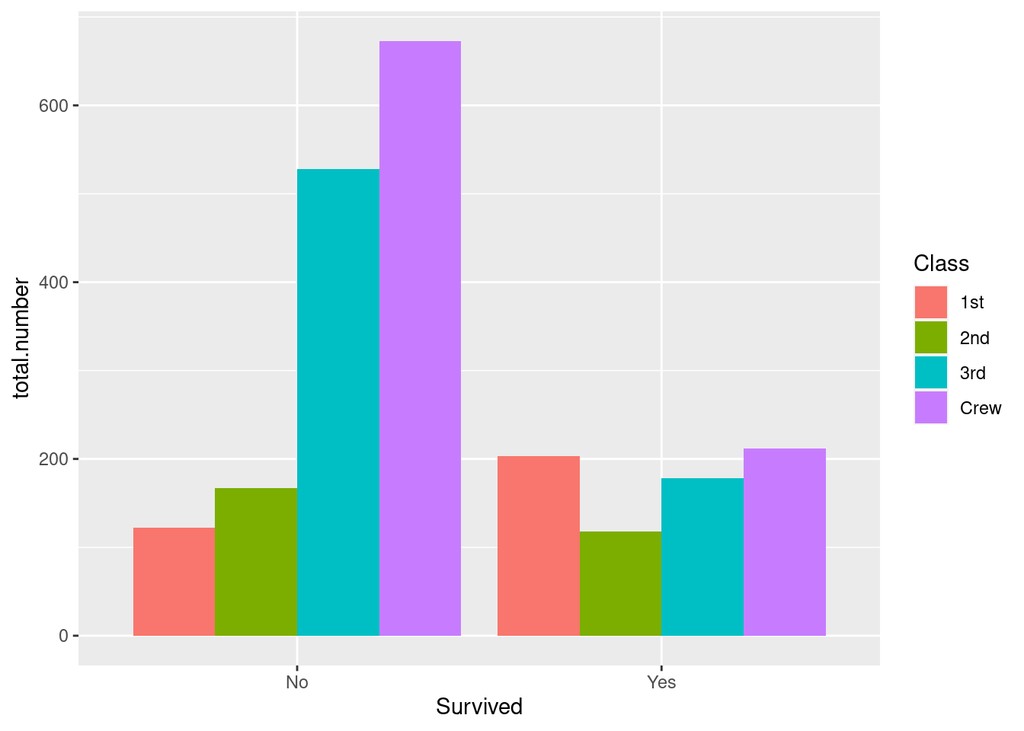

```r
ggplot(totals_class, aes(x = Survived, y = total.number,
fill = Class)) +
geom_bar(stat = 'identity', position = 'dodge')
```

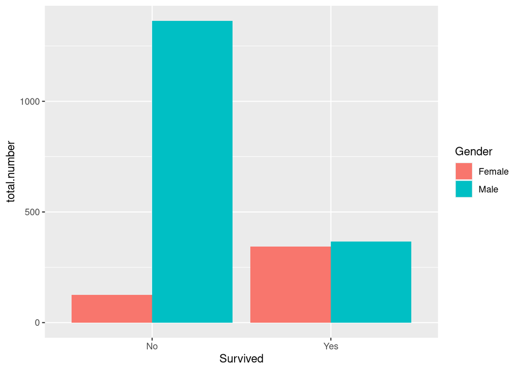

```r
ggplot(totals_gender, aes(x = Survived, y = total.number,
fill = Gender)) +
geom_bar(stat = 'identity', position = 'dodge')
```

```r
# scale_fill_manual(values = c(black = "black", red = "red"))
```

Based on your bar plots, please answer the following questions in the space below.

Questions:

## Question 1: Based on your graphs, do you believe that class played a role in the Titanic passenger survival chances? How about gender? Which do you think was most important and why?

Yes, both class and gender played a role. By considering the survivors are about equal across class and gender, and the non-survivors increase with diminishing class and crew with the most, we can estimate a survival rate for each class. From this we can guess that in order of highest priority to the boats were 1st, 2nd, 3rd, and crew. This could have been incidental, as the decks were organized by class with crew also at the bottom and 1st class closest to the lifeboats. However, we can not say for sure given the varying survivibility of people in cold water.